# Homework 6 Answers

BSTA 550

Modified

November 25, 2026

Below are some select answers from the homework.

## Questions

### 1. Medication absorption (transformed)

$X$ has pdf $f_X(x) = 3x^2$ and CDF $F_X(x) = x^3$ for $0 \leq x \leq 1$.

#### Part a

Let $Y = 100X$. Is this linear or nonlinear? What are the possible values of $Y$? Find $P(Y \leq 50)$ exactly.

Linear, with $0 \leq Y \leq 100$. $P(Y \leq 50) = P(X \leq 0.5) = 0.5^3 = 0.125$

#### Part b

Let $W = -\ln(X)$. Is this linear or nonlinear? What are the possible values of $W$? Find $P(W \leq 0.5)$ exactly.

Not given

#### Part c

Use the simulation method (simulate, transform, summarize) to check your answers to Parts a and b.

$P(Y \leq 50) \approx$ 0.1254

Answers will vary slightly, but should be close to your answers in Parts a and b.

#### Part d

Make a histogram of each of the simulated `x`, `y`, and `w` values. Which transformation kept the shape, and which changed it?

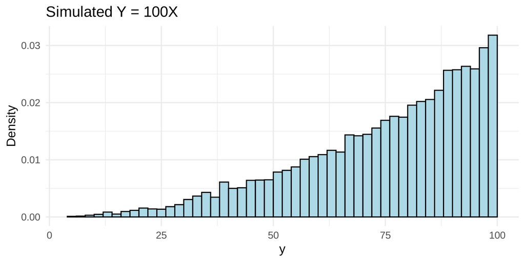

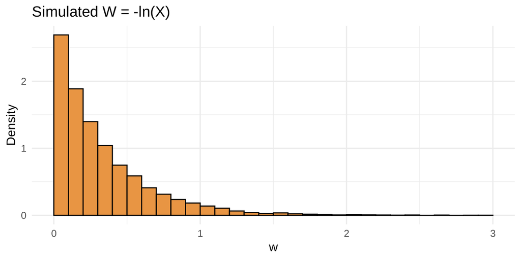

$Y = 100X$ (linear) keeps the shape of $X$, just stretched to 0–100. $W = -\ln(X)$ (nonlinear) changes the shape: it piles up near 0 and has a long right tail.

#### Part e

Add the pdf of an $\text{Exp}(3)$ RV to your histogram of `w`. Does it match? If $W \sim \text{Exp}(3)$, what is $\mathbb{E}[W]$?

Not given

### 2. Smoking policy and education

Let $X=$ highest education level and $Y=$ policy favored, from the table of 300 adults.

#### Part a

Make a table for the joint pmf $p_{X,Y}(x,y)$.

Not given

#### Part b

Find the marginal pmf $p_{X}(x)$.

$p_X(\text{college}) = 0.25$, $p_X(\text{high school}) = 0.50$, $p_X(\text{grade school}) = 0.25$

#### Part c

Find the marginal pmf $p_{Y}(y)$.

Not given

#### Part d

Make a table for the conditional pmf $p_{X|Y}(x|y)$.

Partial answer: $p_{X|Y}(\text{high school} \mid \text{no smoking at all}) = \dfrac{30}{63} \approx 0.476$

#### Part e

Make a table for the conditional pmf $p_{Y|X}(y|x)$.

Partial answer: $p_{Y|X}(\text{no smoking at all} \mid \text{high school}) = \dfrac{30}{150} = 0.200$

#### Part f

Are $X$ and $Y$ independent? Explain using your answers above.

No. For example, $p_{X,Y}(\text{college}, \text{no restrictions}) = \frac{5}{300} \approx 0.017$, but $p_X(\text{college})\,p_Y(\text{no restrictions}) = 0.25 \times \frac{35}{300} \approx 0.029$.

#### Part g

Simulate 10,000 adults by drawing from the table, to check one value from each of Parts a, d, and f.

- Joint $\approx$ 0.0182 and product $\approx$ 0.0292
- $p_{X|Y}(\text{high school} \mid \text{no smoking at all}) \approx$ 0.4615

Answers will vary slightly, but should be close to your answers in Parts a, d, and f.

### 3. Expected value from a joint pdf

Consider the joint density $f_{X,Y}(x,y)= \dfrac32 x y$ for $0 \leq x$, $0 \leq y$, and $x+y \leq 2$.

#### Part a

Draw the possible values of $(X, Y)$.

Not given

#### Part b

Use 2D grid sampling to approximate $\mathbb{E}[X]$ and $\mathbb{E}[Y]$.

$\mathbb{E}[X] \approx$ 0.799 and $\mathbb{E}[Y] \approx$ 0.8

Answers will vary slightly, but should both be close to $\frac45 = 0.8$.

#### Part c

Are $X$ and $Y$ independent? Explain, then check with your simulated pairs from Part b.

No. The possible values are a triangle, not a rectangle: the possible values of $Y$ ($0 \leq y \leq 2 - x$) depend on $x$. In the simulation, joint $\approx$ 0.378 but product $\approx$ 0.474.

### 4. Ratio of two RVs

$X$ and $Y$ have constant joint density on the rectangle $0 \leq x \leq 1$, $\frac{1}{2} \leq y \leq 1$, and $Z = X/Y$.

#### Part a

What is the height of the joint pdf? What are the possible values of $Z$?

The height is 2 (the rectangle’s area is $\frac12$), and $0 \leq Z \leq 2$

#### Part b

Rewrite the event $Z \leq 1$ as a region of $(x, y)$ points, and find $P(Z \leq 1)$ using areas.

Not given

#### Part c

Simulate 10,000 pairs $(X, Y)$ to check your answer to Part b, and make a histogram of $Z$.

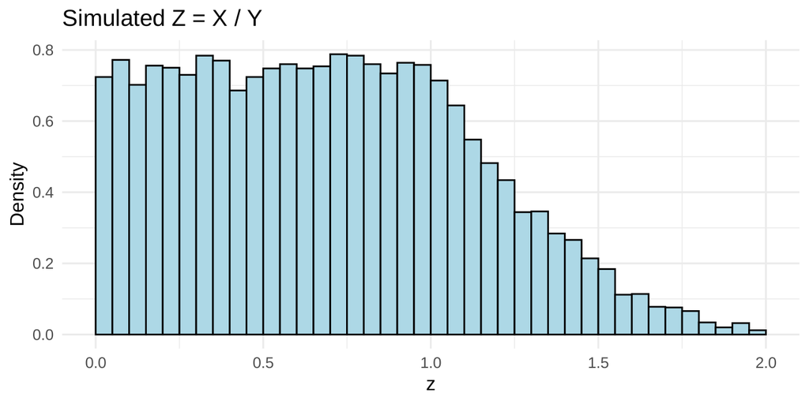

The simulated $P(Z \leq 1)$ should be close to your answer in Part b.

### 5. Maude’s phone and breakfast

Let $X$ be the number of days until Maude first loses her cell phone (1% chance each day), and $Y$ the number of days until she first forgets to eat breakfast (3% chance each day). $X$ and $Y$ are independent.

#### Part a

Find the joint pmf of $X$ and $Y$.

$p_{X,Y}(x,y) = \left[0.99^{x-1}(0.01)\right]\left[0.97^{y-1}(0.03)\right]$ for $x = 1, 2, 3, \ldots$ and $y = 1, 2, 3, \ldots$

#### Part b

Find the joint CDF of $X$ and $Y$ and briefly explain what $F_{X,Y}(x,y)$ represents.

Not given

#### Part c

Find the conditional pmf $p_{Y|X}(y|x)$.

$p_{Y|X}(y|x) = 0.97^{y-1}(0.03)$ for $y = 1, 2, 3, \ldots$ (the same as $p_Y(y)$, since $X$ and $Y$ are independent)

#### Part d

Find $F_{X,Y}(30, 10)$, then simulate 10,000 pairs of $(X, Y)$ to check your answer.

- Exact: $F_{X,Y}(30, 10) \approx 0.0683$
- Simulated: $\approx$ 0.0689

Answers will vary slightly, but should be close to 0.0683.

### 6. Minimum of a uniform and an exponential

$X$ and $Y$ are independent with $f_X(x)=\frac{1}{5}$ for $0\leq x\leq 5$ and $f_Y(y)=2e^{-2y}$ for $y>0$, and $Z = \min(X, Y)$.

#### Part a

Find the joint pdf $f_{X,Y}(x,y)$.

Not given

#### Part b

What are the possible values of $Z$? Find $P(Z > 0.5)$ exactly.

$0 \leq Z \leq 5$, and $P(Z > 0.5) = P(X > 0.5)\,P(Y > 0.5) = \dfrac{4.5}{5}e^{-1} \approx 0.3311$

#### Part c

Find the CDF of $Z$ for $0 \leq z \leq 5$.

Not given

#### Part d

Simulate 10,000 pairs of $(X, Y)$ to approximate $P(X < Y)$ and to check your answers to Parts b and c.

- $P(X < Y) \approx$ 0.1007
- $P(Z > 0.5) \approx$ 0.3349

Answers will vary slightly, but should be close to your answers in Parts b and c.

### 7. Constant density on a quadrilateral

$X$ and $Y$ have constant joint density on the quadrilateral with vertices $(0,0)$, $(2,0)$, $(2,6)$, $(0,12)$.

#### Part a

For $0 \leq y \leq 6$, find the conditional density $f_{X|Y}(x|y)$.

$f_{X|Y}(x|y) = \dfrac{1}{2}$ for $0 \leq x \leq 2$

#### Part b

For $6 \leq y \leq 12$, find the conditional density $f_{X|Y}(x|y)$.

Not given

#### Part c

Find $P(0.5 \leq X \leq 3 \mid Y=7)$.

$0.7$

#### Part d

Simulate 10,000 values of $X$ given $Y = 7$ to check your answer to Part c.

$P(0.5 \leq X \leq 3 \mid Y=7) \approx$ 0.7035

Answers will vary slightly, but should be close to 0.7.